# Kolleg Europa - Social Network Analysis

### Eigenvector-Centrality

> Erinnerung eigenvector: Ein Knoten ist wichtig, wenn er mit anderen wichtigen Knoten verbunden ist.

```r
r_eigen <- eigen_centrality(rd_hosts)
data.frame(r_eigen$vector) %>%
  round(6) %>%
  datatable(options = list(pageLength = 20))
```

|  | r_eigen.vector |
| --- | --- |
| USA | 1 |
| MEX | 0.215922 |
| CHN | 0.601574 |
| IDN | 0.119126 |
| SGP | 0.181774 |
| ISL | 0.130546 |
| IND | 0.283944 |
| GHA | 0.12569 |
| RUS | 0.616024 |
| UKR | 0.523595 |

[output cut: 115 more lines]

Alle Ergebnisse gesammelt und in sortierbarer Tabelle:

```r
results_df <- data.frame(r_degree,r_closeness, r_betweenness, r_eigen$vector) %>%
  rownames_to_column() %>% as_tibble() %>%
  mutate_if(is.numeric, round, 4) %>%
  arrange(rowname)

datatable(results_df, options = list(pageLength = 20))
```

|  | rowname | r_degree | r_closeness | r_betweenness | r_eigen.vector |
| --- | --- | --- | --- | --- | --- |
| 1 | ABW | 20 | 0.0033 | 35.2206 | 0.0059 |
| 2 | AFG | 97 | 0.0031 | 8.0773 | 0.1589 |
| 3 | AGO | 103 | 0.0039 | 68.7602 | 0.1146 |
| 4 | ALB | 111 | 0.0039 | 114.0307 | 0.1288 |
| 5 | AND | 66 | 0.0035 | 27.8488 | 0.0476 |
| 6 | ARE | 111 | 0.0036 | 57.2573 | 0.3377 |
| 7 | ARG | 93 | 0.0033 | 33.5179 | 0.2016 |
| 8 | ARM | 109 | 0.0031 | 15.8786 | 0.2094 |
| 9 | AUS | 92 | 0.0036 | 52.1597 | 0.1862 |
| 10 | AZE | 112 | 0.0033 | 18.8397 | 0.204 |

[output cut: 115 more lines]

## Subgroups and communities

### Transitivität

> Transitivität ist definiert als das Verhältnis geschlossener Dreiecke (Triaden, bei denen alle drei Bindungen beobachtet werden) zur Gesamtzahl aller möglichen Dreiecke (Triaden, bei denen entweder zwei oder alle drei Bindungen beobachtet werden).

```r
transitivity(rd_hosts)
```

```
## [1] 0.8036498
```

### Größte Clique

```r
#cliques(rd_hosts) # list of cliques
largest_cliques(rd_hosts)
```

```
## [[1]]
## + 67/125 vertices, named, from bd77a5e:
##  [1] USA TUR CHN SRB AZE DZA CAN ARM MAR QAT MLI SEN IDN GMB COL ALB CHE
## [18] UKR SAU GEO ISR ARE GHA KOR AGO UZB TCD DJI NZL LBN MKD SOM BGD VAT
## [35] MDA UGA AFG BLR MNE THA NOR KSV SLE KAZ MUS ISL URY MNG LIE VNM KGZ
## [52] CRI PRY SDN RWA NAM ZMB SYC MHL CAF KIR BRN KHM HTI JAM COM SUR
```

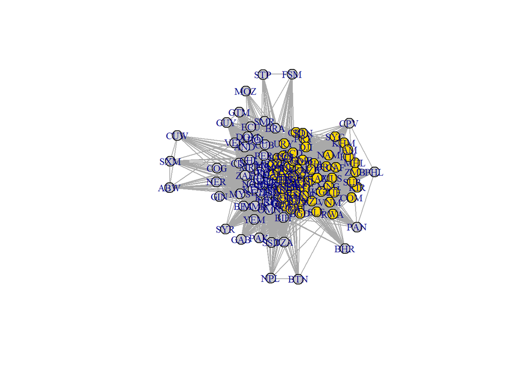

```r
vcol <- rep("grey80", vcount(rd_hosts))
vcol[unlist(largest_cliques(rd_hosts))] <- "gold"
plot(as.undirected(rd_hosts), vertex.label=V(rd_hosts)$name, vertex.color=vcol,
     vertex.label.cex = 0.8,
     vertex.size = 10)
```

### Community detection

```r
ceb <- cluster_edge_betweenness(rd_hosts)
```

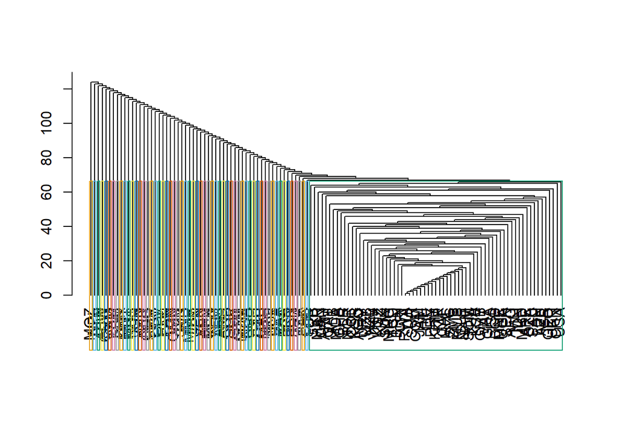

```r
cle <- cluster_leading_eigen(rd_hosts)

#cop <- cluster_optimal(rd_hosts)

dendPlot(ceb, mode="hclust")
```

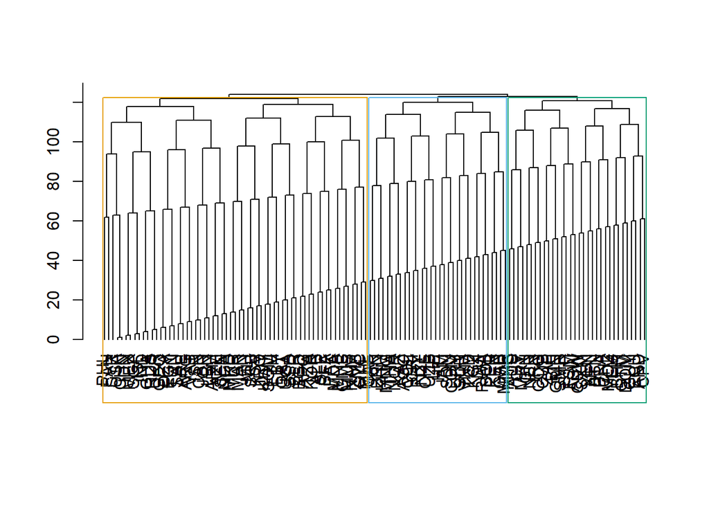

```r
dendPlot(cle, mode="hclust")
```

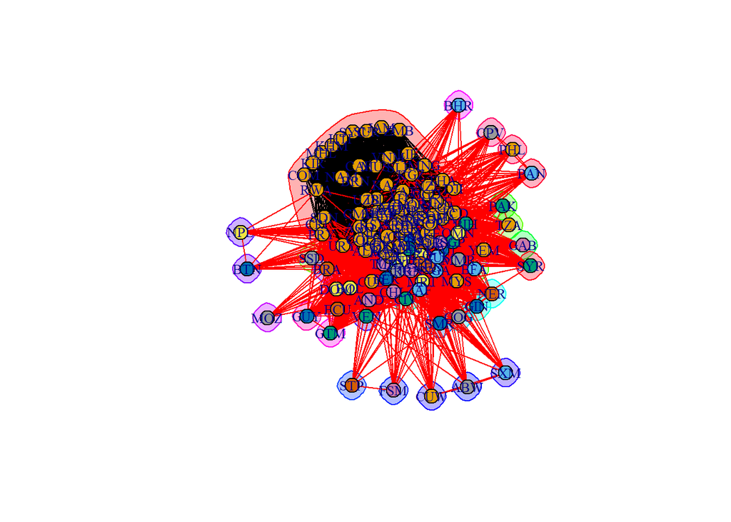

```r
plot(ceb,rd_hosts,
     vertex.label.cex = 0.8,
     vertex.size = 10)
```

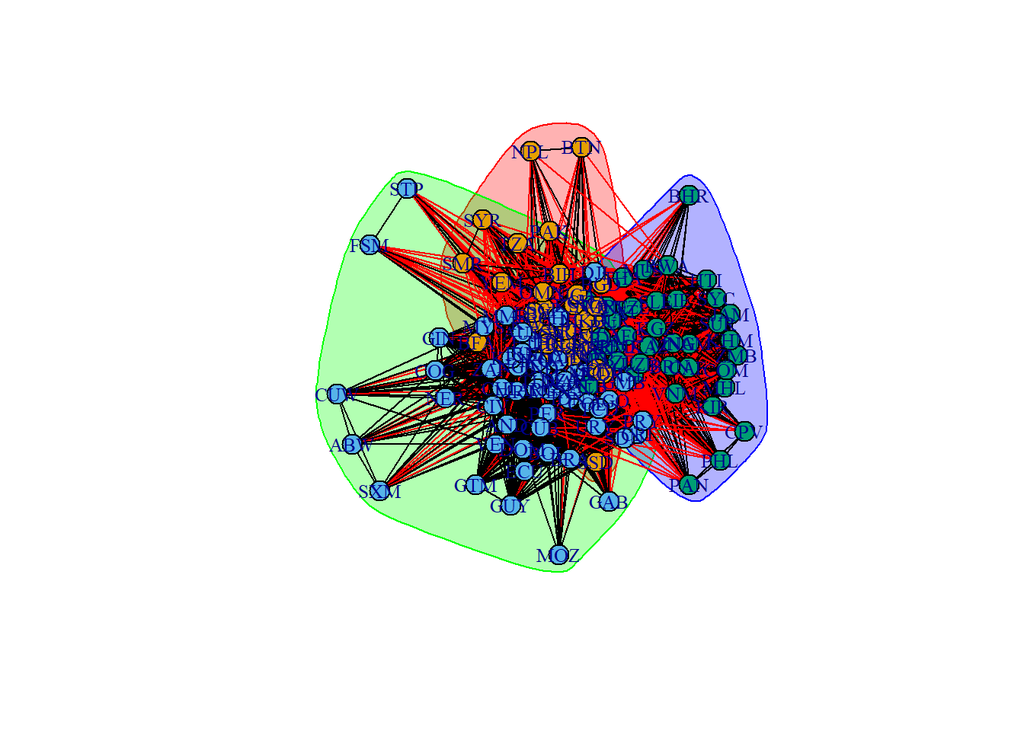

```r
plot(cle,rd_hosts,
     vertex.label.cex = 0.8,
     vertex.size = 10)
```

```r
#plot(cop,rd_hosts,
#     vertex.label.cex = 0.8,
#     vertex.size = 10)
```

# Exponential Random Graph Models

Wie “besonders” sind unsere Projektionsnetzwerke, im Vergleich zu ähnlich aufgebauten Netzwerken?

```r
g_random <- vector('list',1000)

for(i in 1:1000){

  g_random[[i]] <- sample_gnp(n = gorder(rd_hosts),
                              p = edge_density(rd_hosts),
                              directed = FALSE)
}

# apply mean_distance on every graph
g_random_meandis <- unlist(lapply(g_random, mean_distance, directed = FALSE))

mean_distance(rd_hosts, directed = FALSE)
```

```
## [1] 1.361935
```

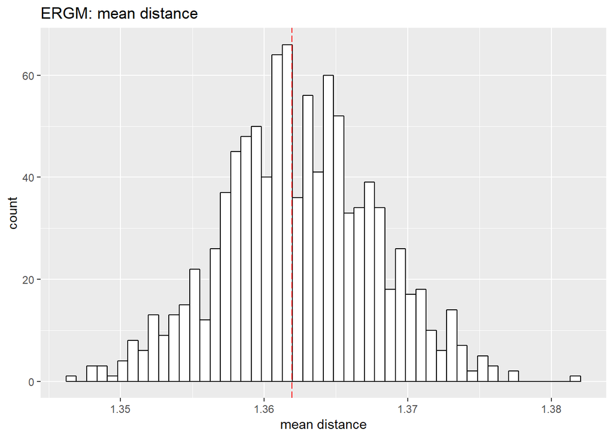

```r
# graphical comparison to original network
ggplot() +
  aes(g_random_meandis)+
  geom_histogram(bins = 50, colour="black", fill="white")+
  geom_vline(xintercept = mean_distance(rd_hosts, directed = FALSE), colour="red", linetype = "longdash")+
  labs(title = "ERGM: mean distance",
       x = "mean distance")
```

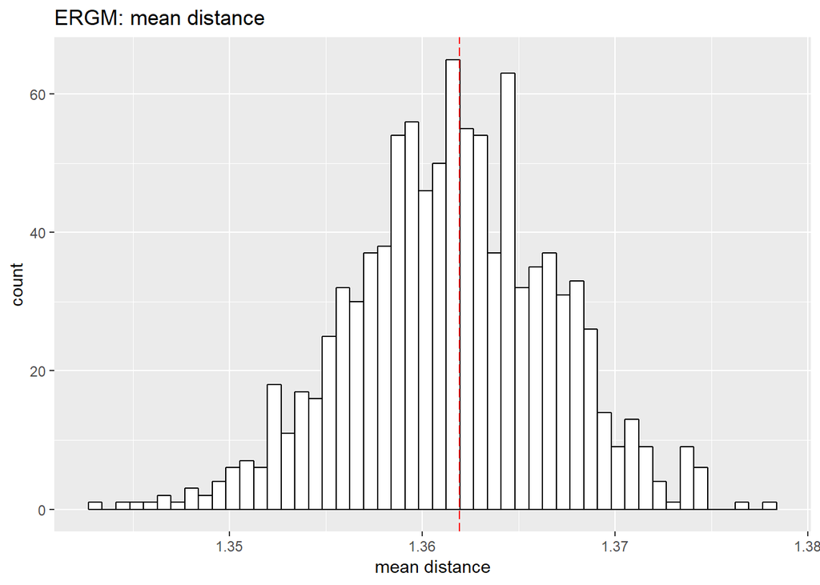

```r
g_random <- vector('list',1000)

for(i in 1:1000){

  g_random[[i]] <- sample_gnp(n = gorder(rd_hosts),
                              p = edge_density(rd_hosts),
                              directed = FALSE)
}

# apply mean_distance on every graph
g_random_meandis <- unlist(lapply(g_random, mean_distance, directed = FALSE))

g_random_diameter <- unlist(lapply(g_random, diameter, directed = FALSE))

g_random_transitivity <- unlist(lapply(g_random, transitivity))

ggplot() +
  aes(g_random_meandis)+
  geom_histogram(bins = 50, colour="black", fill="white")+
  geom_vline(xintercept = mean_distance(rd_hosts, directed = FALSE), colour="red", linetype = "longdash")+
  labs(title = "ERGM: mean distance",
       x = "mean distance")
```

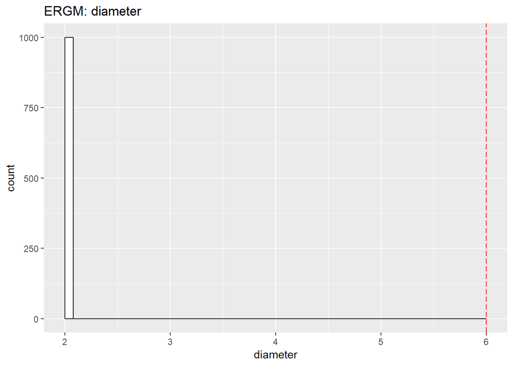

```r
ggplot() +
  aes(g_random_diameter)+
  geom_histogram(bins = 50, colour="black", fill="white")+
  geom_vline(xintercept = diameter(rd_hosts, directed = FALSE), colour="red", linetype = "longdash")+
  labs(title = "ERGM: diameter",
       x = "diameter")
```

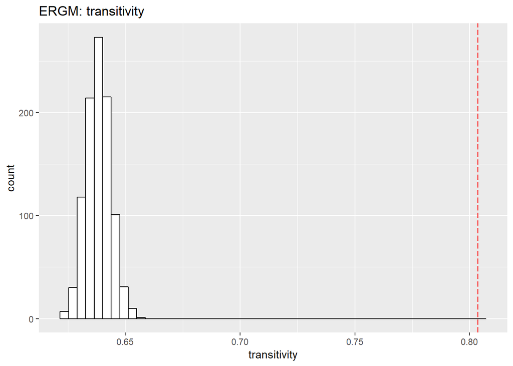

```r
ggplot() +
  aes(g_random_transitivity)+
  geom_histogram(bins = 50, colour="black", fill="white")+
  geom_vline(xintercept = transitivity(rd_hosts), colour="red", linetype = "longdash")+
  labs(title = "ERGM: transitivity",
       x = "transitivity")
```